# Econometrics Homework 1

Charles Reid

9/14/2020

## What are the names of the people in your study group?

- Nikki
- Chistopher
- Musbaou
- Isabella
- Mostafa
- Charles

## Do about 20 experiments where you roll a dice and record whether the result is a 6 or not.

```r
Dice_Experiment <- sample(x = 1:6, size = 20, replace = TRUE)

Dice_Experiment
```

```
##  [1] 4 3 2 6 6 1 1 2 2 4 5 3 6 3 2 6 1 5 2 6
```

```r
sum(Dice_Experiment == 6)
```

```
## [1] 5
```

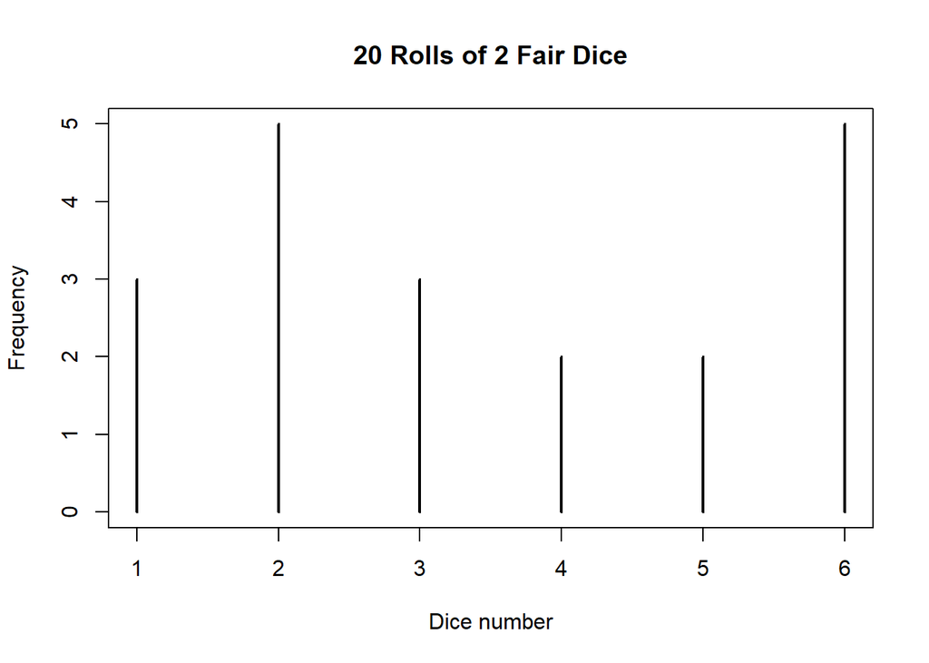

```r
plot(table(Dice_Experiment), xlab = 'Dice number', ylab = 'Frequency', main = '20 Rolls of 2 Fair Dice')
```

## “Adjust” the dice. Can you get them to roll a 6 more or less often than would be expected? How would you know - what is “more often”? Can you write some code in R that will simulate a fair roll?

```r
Unfair_Dice_Experiment <- sample(x = 1:6, size = 20, replace = TRUE, prob = c(0.2, 0.1, 0.1, 0.05, 0.05, 0.5))

Unfair_Dice_Experiment
```

```
##  [1] 3 6 6 6 4 2 6 3 3 6 6 2 2 1 1 6 1 6 6 2
```

```r
sum(Unfair_Dice_Experiment == 6)
```

```
## [1] 9
```

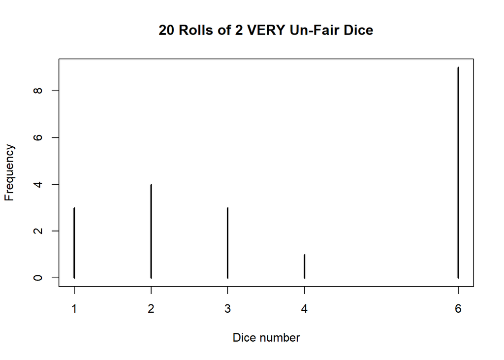

```r
plot(table(Unfair_Dice_Experiment), xlab = 'Dice number', ylab = 'Frequency', main = '20 Rolls of 2 VERY Un-Fair Dice')
```

## Replicate the commands given in the lecture notes R Basics for Lecture 1.

```r
load("acs2017_ny_data.RData")
acs2017_ny[1:10,1:7]
```

```
##    AGE female educ_nohs educ_hs educ_somecoll educ_college educ_advdeg
## 1   72      1         0       0             0            0           1
## 2   72      0         0       0             0            0           1
## 3   31      0         0       0             0            1           0
## 4   28      1         0       0             0            1           0
## 5   54      0         0       0             0            0           1
## 6   45      1         0       1             0            0           0
## 7   84      1         0       0             1            0           0
## 8   71      0         0       0             0            1           0
## 9   68      1         0       0             1            0           0
## 10  37      1         1       0             0            0           0
```

```r
attach(acs2017_ny)
```

```r
summary(acs2017_ny)
```

```
##       AGE            female         educ_nohs        educ_hs
##  Min.   : 0.00   Min.   :0.0000   Min.   :0.000   Min.   :0.0000
##  1st Qu.:22.00   1st Qu.:0.0000   1st Qu.:0.000   1st Qu.:0.0000
##  Median :42.00   Median :1.0000   Median :0.000   Median :0.0000
##  Mean   :41.57   Mean   :0.5156   Mean   :0.271   Mean   :0.2804
##  3rd Qu.:60.00   3rd Qu.:1.0000   3rd Qu.:1.000   3rd Qu.:1.0000
##  Max.   :95.00   Max.   :1.0000   Max.   :1.000   Max.   :1.0000
##
##  educ_somecoll    educ_college     educ_advdeg                  SCHOOL
##  Min.   :0.000   Min.   :0.0000   Min.   :0.000   N/A              :  5569
##  1st Qu.:0.000   1st Qu.:0.0000   1st Qu.:0.000   No, not in school:144968
##  Median :0.000   Median :0.0000   Median :0.000   Yes, in school   : 46048
##  Mean   :0.173   Mean   :0.1567   Mean   :0.119   Missing          :     0
##  3rd Qu.:0.000   3rd Qu.:0.0000   3rd Qu.:0.000
##  Max.   :1.000   Max.   :1.0000   Max.   :1.000
##
##                         EDUC
##  Grade 12                 :55119
##  4 years of college       :30802
##  5+ years of college      :23385
##  1 year of college        :19947
##  Nursery school to grade 4:14240
##  2 years of college       :14065
##  (Other)                  :39027
##                                           EDUCD
##  Regular high school diploma                 :35689
##  Bachelor's degree                           :30802
##  1 or more years of college credit, no degree:19947
##  Master's degree                             :17010
##  Associate's degree, type not specified      :14065
##  Some college, but less than 1 year          : 9086
##  (Other)                                     :69986
##                                      DEGFIELD
##  N/A                                     :142398
##  Business                                :  9802
##  Education Administration and Teaching   :  6708
##  Social Sciences                         :  4836
##  Medical and Health Sciences and Services:  3919
##  Fine Arts                               :  3491
##  (Other)                                 : 25431
```

[output cut: 209 more lines]

```
##  Min.   :0.00000   Min.   :0.00000   Min.   :0.000     Min.   :0.0000
##  1st Qu.:0.00000   1st Qu.:0.00000   1st Qu.:0.000     1st Qu.:0.0000
##  Median :0.00000   Median :0.00000   Median :0.000     Median :0.0000
##  Mean   :0.01332   Mean   :0.05506   Mean   :0.122     Mean   :0.1965
##  3rd Qu.:0.00000   3rd Qu.:0.00000   3rd Qu.:0.000     3rd Qu.:0.0000
##  Max.   :1.00000   Max.   :1.00000   Max.   :1.000     Max.   :1.0000
##
##  below_200poverty   foodstamps
##  Min.   :0.0000   Min.   :0.0000
##  1st Qu.:0.0000   1st Qu.:0.0000
##  Median :0.0000   Median :0.0000
##  Mean   :0.2676   Mean   :0.1465
##  3rd Qu.:1.0000   3rd Qu.:0.0000
##  Max.   :1.0000   Max.   :1.0000
##
```

196585 people are in the data set.

```r
print(NN_obs <- length(AGE))
```

```
## [1] 196585
```

## Do some simple stats on the PUMS-NY data:

Summary of Females

```r
summary(AGE[female ==1])
```

```
##    Min. 1st Qu.  Median    Mean 3rd Qu.    Max.
##    0.00   23.00   44.00   42.72   61.00   95.00
```

Summary of Non-females.

```r
summary(AGE[!female])
```

```
##    Min. 1st Qu.  Median    Mean 3rd Qu.    Max.
##    0.00   21.00   40.00   40.35   59.00   95.00
```

Those notes request that you find average ages for: men

```r
mean(AGE[!female == 1])
```

```
## [1] 40.35398
```

and women after accounting for the top-coding.

```r
mean(AGE[female == 1])
```

```
## [1] 42.71629
```

Tell me something else interesting, that you learned from the data:

What is surpizing is that women tend to be a little older, about two years older than men.

```r
summary(EDUC[female == 1])
```

```
##       N/A or no schooling Nursery school to grade 4       Grade 5, 6, 7, or 8
##                      5844                      7112                      6302
##                   Grade 9                  Grade 10                  Grade 11
##                      2046                      2269                      2514
##                  Grade 12         1 year of college        2 years of college
##                     27810                     10193                      7972
##        3 years of college        4 years of college       5+ years of college
##                         0                     16170                     13131
```

```r
summary(EDUC[!female])
```

```
##       N/A or no schooling Nursery school to grade 4       Grade 5, 6, 7, or 8
##                      6035                      7128                      6777
##                   Grade 9                  Grade 10                  Grade 11
##                      2042                      2375                      2823
##                  Grade 12         1 year of college        2 years of college
##                     27309                      9754                      6093
##        3 years of college        4 years of college       5+ years of college
##                         0                     14632                     10254
```

Both genders have a mean education of about 15:

```r
mean(educ_college [female == 1])*100
```

```
## [1] 15.95257
```

```r
mean(educ_college [!female])*100
```

```
## [1] 15.3662
```

For example about educational attainments in different neighborhoods in the city. Are there surprises for you?:

```r
summary(EDUC[in_Brooklyn])
```

```
##       N/A or no schooling Nursery school to grade 4       Grade 5, 6, 7, or 8
##                         0                         0                         0
##                   Grade 9                  Grade 10                  Grade 11
##                         0                         0                         0
##                  Grade 12         1 year of college        2 years of college
##                         0                         0                         0
##        3 years of college        4 years of college       5+ years of college
##                         0                         0                     24764
```

```r
summary(EDUC[in_Queens])
```

```
##       N/A or no schooling Nursery school to grade 4       Grade 5, 6, 7, or 8
##                         0                         0                         0
##                   Grade 9                  Grade 10                  Grade 11
##                         0                         0                         0
##                  Grade 12         1 year of college        2 years of college
##                         0                         0                         0
##        3 years of college        4 years of college       5+ years of college
##                         0                         0                     21841
```

```r
summary(EDUC[in_Bronx])
```

```
##       N/A or no schooling Nursery school to grade 4       Grade 5, 6, 7, or 8
##                         0                         0                         0
##                   Grade 9                  Grade 10                  Grade 11
##                         0                         0                         0
##                  Grade 12         1 year of college        2 years of college
##                         0                         0                         0
##        3 years of college        4 years of college       5+ years of college
##                         0                         0                     10577
```

```r
summary(EDUC[in_Manhattan])
```

```
##       N/A or no schooling Nursery school to grade 4       Grade 5, 6, 7, or 8
##                         0                         0                         0
##                   Grade 9                  Grade 10                  Grade 11
##                         0                         0                         0
##                  Grade 12         1 year of college        2 years of college
##                         0                         0                         0
##        3 years of college        4 years of college       5+ years of college
##                         0                         0                      9792
```

```r
summary(EDUC[in_Westchester])
```

```
##       N/A or no schooling Nursery school to grade 4       Grade 5, 6, 7, or 8
##                         0                         0                         0
##                   Grade 9                  Grade 10                  Grade 11
##                         0                         0                         0
##                  Grade 12         1 year of college        2 years of college
##                         0                         0                         0
##        3 years of college        4 years of college       5+ years of college
##                         0                         0                      8676
```

People in Brooklyn have the highest level of education.

```r
options(readr.num_columns = 0)
library(readr)
S_P_Stock_Price <- read_csv("all_stocks_5yr.csv")

head(S_P_Stock_Price)
```

```
## # A tibble: 6 x 7
##   date        open  high   low close   volume Name
##   <date>     <dbl> <dbl> <dbl> <dbl>    <dbl> <chr>
## 1 2013-02-08  15.1  15.1  14.6  14.8  8407500 AAL
## 2 2013-02-11  14.9  15.0  14.3  14.5  8882000 AAL
## 3 2013-02-12  14.4  14.5  14.1  14.3  8126000 AAL
## 4 2013-02-13  14.3  14.9  14.2  14.7 10259500 AAL
## 5 2013-02-14  14.9  15.0  13.2  14.0 31879900 AAL
## 6 2013-02-15  13.9  14.6  13.9  14.5 15628000 AAL
```

Adj close numbers

```r
S_P_Stock_Price[1:30, "close"]
```

```
## # A tibble: 30 x 1
##    close
##    <dbl>
##  1  14.8
##  2  14.5
##  3  14.3
##  4  14.7
##  5  14.0
##  6  14.5
##  7  14.3
##  8  13.3
##  9  13.4
## 10  13.6
## # ... with 20 more rows
```

Isolated closing price and

```r
sp_pricedate <-S_P_Stock_Price[, "date", drop = FALSE]
sp_pricenew <-S_P_Stock_Price[, "close", drop = FALSE]
cbind(sp_pricedate,sp_pricenew)
```

```
##             date     close
## 1     2013-02-08   14.7500
## 2     2013-02-11   14.4600
## 3     2013-02-12   14.2700
## 4     2013-02-13   14.6600
## 5     2013-02-14   13.9900
## 6     2013-02-15   14.5000
## 7     2013-02-19   14.2600
## 8     2013-02-20   13.3300
## 9     2013-02-21   13.3700
## 10    2013-02-22   13.5700
## 11    2013-02-25   13.0200
## 12    2013-02-26   13.2600
## 13    2013-02-27   13.4100
## 14    2013-02-28   13.4300
```

[output cut: 49986 more lines]

Calculating Close Returns

```r
n <-nrow(sp_pricenew)
sp_returns <- log(sp_pricenew[2:n,1])-log(sp_pricenew[1:(n-1),1])
returns <- sp_returns*100
summary(returns)
```

```
##      close
##  Min.   :-441.6833
##  1st Qu.:  -0.6833
##  Median :   0.0631
##  Mean   :   0.0003
##  3rd Qu.:   0.8073
##  Max.   : 302.8410
```

```r
xdate <- sp_pricedate[2:619040,"date"]
df1 <- cbind.data.frame(xdate,returns)
print(df1)
```

```
##             date         close
## 1     2013-02-11 -1.985687e+00
## 2     2013-02-12 -1.322679e+00
## 3     2013-02-13  2.696326e+00
## 4     2013-02-14 -4.677991e+00
## 5     2013-02-15  3.580586e+00
## 6     2013-02-19 -1.669023e+00
## 7     2013-02-20 -6.744128e+00
## 8     2013-02-21  2.996257e-01
## 9     2013-02-22  1.484808e+00
## 10    2013-02-25 -4.137484e+00
## 11    2013-02-26  1.826535e+00
## 12    2013-02-27  1.124871e+00
## 13    2013-02-28  1.490313e-01
## 14    2013-03-01  1.331381e+00
```

[output cut: 49986 more lines]

A hot-hand fallacy occurs when gamblers think that a winning streak is more likely to continue.